# Phasors

A 50 kVA, 2400/240 V, 50 Hz distribution transformer (see the equivalent circuit shown below) has a leakage impedance of $0.72 + j\,0.92\,\Omega$ in the high-voltage winding and $0.007 + j\,0.009\,\Omega$ in the low-voltage winding. At the rated voltage and frequency, $R_c'$ and $X_m'$ (i.e., $R_c$ and $X_m$ viewed from the LV side) are $308.4\,\Omega$ and $44.63\,\Omega$, respectively. The transformer delivers $40\,kW$ at $240\,V$ at a lagging power factor of 0.8 to a load $R_L + j\,X_L$ on the LV side.

1. Determine $R_L$ and $X_L$.
2. Determine ${\bf{V}}_p$ (magnitude and phase) such that the load voltage is $240\angle 0$ V (rms).
3. Draw the phasor diagram showing the relationship between ${\bf{V}}_p$, ${\bf{V}}_m$, and ${\bf{V}}_s'$.

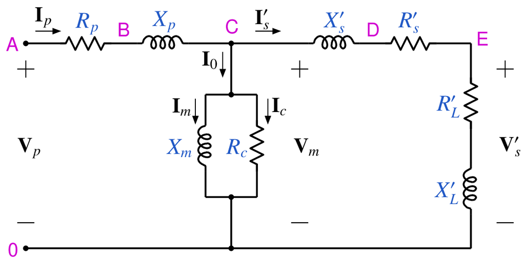

```python
from IPython.display import Image
Image(filename =r'phasor_12_fig_1.png', width=500)
```

```python
# run this cell to view the circuit file.
%pycat phasor_12_orig.in
```

We now replace strings such as \$Rp with the value of our choice by running the python script given below. It takes an existing circuit file `phasor_12_orig.in` and produces a new circuit file `phasor_12.in`, after replacing \$Rp etc with the values of our choice.

```python
import gseim_calc as calc
import numpy as np

Vs_rms = 2500.0 # to be changed by user
s_Vs_phi = "0.5" # (degrees) to be changed by user
RLs = 0.5 # to be changed by user
XLs = 0.2 # to be changed by user

n = 10.0 # turns ratio
n2 = float(n*n)

Rp = 0.72
Xp = 0.92
Rs = 0.007
Xs = 0.009
Xms = 44.63
Rcs = 308.4

Vs = Vs_rms*np.sqrt(2.0)

Rsp = Rs*n2
Xsp = Xs*n2
Xm = Xms*n2
Rc = Rcs*n2
RLp = RLs*n2
XLp = XLs*n2

f = 50.0
omg = 2.0*np.pi*f
Lp = Xp/omg
Lsp = Xsp/omg
Lm = Xm/omg
LLp = XLp/omg

s_Vs_mag = ("%11.4E"%(Vs)).strip()

s_Rp  = ("%11.4E"%(Rp )).strip()
s_Rc  = ("%11.4E"%(Rc )).strip()
s_Rsp = ("%11.4E"%(Rsp)).strip()
s_Lp  = ("%11.4E"%(Lp )).strip()
s_Lm  = ("%11.4E"%(Lm )).strip()
s_Lsp = ("%11.4E"%(Lsp)).strip()
s_RLp = ("%11.4E"%(RLp)).strip()
s_LLp = ("%11.4E"%(LLp)).strip()

l = [
  ('$Vs_mag', s_Vs_mag),
  ('$Vs_phi', s_Vs_phi),
  ('$Rp',  s_Rp),
  ('$Rc',  s_Rc),
  ('$Rsp', s_Rsp),
  ('$Lp',  s_Lp),
  ('$Lm',  s_Lm),
  ('$Lsp', s_Lsp),
  ('$RLp', s_RLp),
  ('$LLp', s_LLp),
]
calc.replace_strings_1("phasor_12_orig.in", "phasor_12.in", l)
print('phasor_12.in is ready for execution')
```

```
phasor_12.in is ready for execution
```

```python
import os
import dos_unix
# uncomment for windows:
#dos_unix.d2u("phasor_12.in")
os.system('run_gseim phasor_12.in')
```

```
Circuit: filename = phasor_12.in
GSEIM: Program completed.
```

```
0
```

The circuit file (`phasor_12.in`) is created in the same directory as that used for launching Jupyter notebook. The last step (i.e., running `GSEIM` on `phasor_12.in`) creates data files `phasor_12_1.dat` and `phasor_12_2.dat` in the same directory. We can now use the python code below to compute and display the quantities of interest.

```
filename: phasor_12_1.dat
filename: phasor_12_2.dat
phi_Vsp: -6.8495E-01 deg
phi_Isp: -2.2486E+01 deg
PL:  1.0011E+05
power factor:  0.9285
voltage phasors in rectangular form:
Vm: (3470.21,   -5.06)
Vp: (3535.37,   30.85)
Vsp: (3407.50,  -40.74)
voltage phasors in polar form:
Vm: magnitude: 3470.21, angle:   -0.08 deg
Vp: magnitude: 3535.50, angle:    0.50 deg
Vsp: magnitude: 3407.74, angle:   -0.68 deg
current phasors in rectangular form:
Ic: (   0.11,   -0.00)
Im: (  -0.00,   -0.78)
Ip: (  58.58,  -24.98)
Isp: (  58.47,  -24.20)
current phasors in polar form:
Ic: magnitude:    0.11, angle:   -0.08 deg
Im: magnitude:    0.78, angle:  -90.08 deg
Ip: magnitude:   63.68, angle:  -23.09 deg
Isp: magnitude:   63.28, angle:  -22.49 deg
```

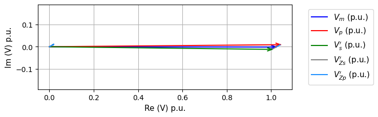

```python
import numpy as np
import gseim_calc as calc
import matplotlib.pyplot as plt
from matplotlib.ticker import (MultipleLocator, AutoMinorLocator)
from setsize import set_size
import cmath

rad_to_deg = 180.0/np.pi

slv = calc.slv("phasor_12.in")

i_slv = 0
i_out = 0
filename = slv.l_filename_all[i_slv][i_out]
print('filename:', filename)
u = np.loadtxt(filename)

Ic  = slv.get_scalar_complex_1(i_slv, i_out, "Ic",  u)
Im  = slv.get_scalar_complex_1(i_slv, i_out, "Im",  u)
Ip  = slv.get_scalar_complex_1(i_slv, i_out, "Ip",  u)
Isp = slv.get_scalar_complex_1(i_slv, i_out, "Isp", u)

i_slv = 0
i_out = 1
filename = slv.l_filename_all[i_slv][i_out]
print('filename:', filename)
u = np.loadtxt(filename)

Vm  = slv.get_scalar_complex_1(i_slv, i_out, "Vm",  u)
Vp  = slv.get_scalar_complex_1(i_slv, i_out, "Vp",  u)
Vsp = slv.get_scalar_complex_1(i_slv, i_out, "Vsp", u)

# compute power delivered to load and p.f.

phi_Isp = cmath.phase(Isp)
phi_Vsp = cmath.phase(Vsp)
phi = phi_Vsp - phi_Isp

print('phi_Vsp:', "%11.4E"%(phi_Vsp*180.0/np.pi), 'deg')
print('phi_Isp:', "%11.4E"%(phi_Isp*180.0/np.pi), 'deg')

pf = np.cos(phi)
PL = 0.5*abs(Vsp)*abs(Isp)*pf
print('PL:', "%11.4E"%PL)
print('power factor:', "%7.4f"%pf)

print('voltage phasors in rectangular form:')

s_format = "%7.2f"

calc.print_complex_rect('Vm',  Vm,  s_format)
calc.print_complex_rect('Vp',  Vp,  s_format)
calc.print_complex_rect('Vsp', Vsp, s_format)

print('voltage phasors in polar form:')

calc.print_complex_polar('Vm',  Vm,  s_format)
calc.print_complex_polar('Vp',  Vp,  s_format)
calc.print_complex_polar('Vsp', Vsp, s_format)

print('current phasors in rectangular form:')

calc.print_complex_rect('Ic' , Ic,  s_format)
calc.print_complex_rect('Im' , Im,  s_format)
calc.print_complex_rect('Ip' , Ip,  s_format)
calc.print_complex_rect('Isp', Isp, s_format)

print('current phasors in polar form:')

calc.print_complex_polar('Ic' , Ic,  s_format)
calc.print_complex_polar('Im' , Im,  s_format)
calc.print_complex_polar('Ip' , Ip,  s_format)
calc.print_complex_polar('Isp', Isp, s_format)

# convert to rms and pu

Vscale = 2400.0
sqrt2 = np.sqrt(2.0)

Vm_pu  = Vm/(sqrt2*Vscale)
Vp_pu  = Vp/(sqrt2*Vscale)
Vsp_pu = Vsp/(sqrt2*Vscale)

VZs_pu = Isp*(Rsp + Xsp*(complex(0.0,1.0)))/(sqrt2*Vscale)
VZp_pu = Ip *(Rp  + Xp *(complex(0.0,1.0)))/(sqrt2*Vscale)

l_colors = ["blue", "red", "green", "grey", "dodgerblue",
  "tomato", "brown", "gold", "magenta"]

l1 = []
l1_labels = []

color_Vm_pu  = calc.phasor_append_1a(l1, l1_labels, Vm_pu,  "$V_m$ (p.u.)",     l_colors)
color_Vp_pu  = calc.phasor_append_1a(l1, l1_labels, Vp_pu,  "$V_p$ (p.u.)",     l_colors)
color_Vsp_pu = calc.phasor_append_1a(l1, l1_labels, Vsp_pu, "$V_s'$ (p.u.)",    l_colors)
color_VZs_pu = calc.phasor_append_1a(l1, l1_labels, VZs_pu, "$V_{Zs}'$ (p.u.)", l_colors)
color_VZp_pu = calc.phasor_append_1a(l1, l1_labels, VZp_pu, "$V_{Zp}'$ (p.u.)", l_colors)

theta_deg = 20.0
length_arrow = calc.phasor_3(l1, 0.02)
l1_arrow = calc.phasor_2(l1, theta_deg, length_arrow, 0.2)

l2 = []
l2_colors = []

calc.phasor_append_2(l2, l2_colors, Vsp_pu, (Vsp_pu + VZs_pu), color_VZs_pu)
calc.phasor_append_2(l2, l2_colors, (Vsp_pu + VZs_pu), (Vsp_pu + VZs_pu + VZp_pu), color_VZp_pu)

l2_arrow = calc.phasor_2(l2, theta_deg, length_arrow, 0.2)

fig, ax = plt.subplots()
ax.set_aspect('equal', adjustable='box')
ax.grid()

for i, l_dummy in enumerate(l1_arrow):
    for k, t in enumerate(l_dummy):
        if (k == 0):
            ax.plot(t[0],t[1], color=l_colors[i], label=l1_labels[i])
        else:
            ax.plot(t[0],t[1], color=l_colors[i])

for i, l_dummy in enumerate(l2_arrow):
    for k, t in enumerate(l_dummy):
        ax.plot(t[0],t[1], color=l2_colors[i], linestyle='--', dashes=(4, 2))

calc.revise_axis_limits_1(ax, 3.0)
ax.legend(loc='center left', fontsize=11, bbox_to_anchor=(1.05, 0.5))

plt.xlabel('Re (V) p.u.', fontsize=11)
plt.ylabel('Im (V) p.u.', fontsize=11)
plt.show()
```

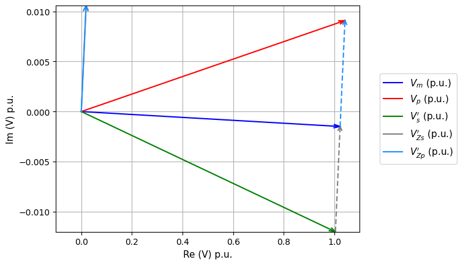

```python
y_max = -100.0
y_min =  100.0

y_min = min(y_min, Vm_pu.imag)
y_min = min(y_min, Vp_pu.imag)
y_min = min(y_min, Vsp_pu.imag)
y_min = min(y_min, VZs_pu.imag)
y_min = min(y_min, VZp_pu.imag)

y_max = max(y_max, Vm_pu.imag)
y_max = max(y_max, Vp_pu.imag)
y_max = max(y_max, Vsp_pu.imag)
y_max = max(y_max, VZs_pu.imag)
y_max = max(y_max, VZp_pu.imag)

x_min = -0.1
x_max = 1.1

x_scale = x_max - x_min
y_scale = y_max - y_min

l1_arrow  = calc.phasor_2A(l1 , theta_deg, length_arrow, 0.2, x_scale, y_scale)
l2_arrow  = calc.phasor_2A(l2 , theta_deg, length_arrow, 0.2, x_scale, y_scale)

fig, ax = plt.subplots()
ax.grid()
ax.set_xlim(x_min, x_max)
ax.set_ylim(y_min, y_max)

for i, l_dummy in enumerate(l1_arrow):
    for k, t in enumerate(l_dummy):
        if (k == 0):
            ax.plot(t[0],t[1], color=l_colors[i], label=l1_labels[i])
        else:
            ax.plot(t[0],t[1], color=l_colors[i])

for i, l_dummy in enumerate(l2_arrow):
    for k, t in enumerate(l_dummy):
        ax.plot(t[0],t[1], color=l2_colors[i], linestyle='--', dashes=(4, 2))

ax.legend(loc='center left', fontsize=11, bbox_to_anchor=(1.05, 0.5))

plt.xlabel('Re (V) p.u.', fontsize=11)
plt.ylabel('Im (V) p.u.', fontsize=11)

plt.show()
```

This notebook was contributed by **Prof. Nakul Narayanan K**, Govt. Engineering College, Thrissur. He may be contacted at nakul@gectcr.ac.in.